# Project Proposal

- Show All Code
- Hide All Code
- View Source

Author

Alexis Hegarty, Ella Smith, Ashlyn Philips, and Amy Truong

```r
library(tidyverse)

co2 <- read_csv("C:\\Users\\lexih\\OneDrive\\Documents\\Stat331\\co2.csv", col_names = TRUE)
cdmt <- read_csv("C:\\Users\\lexih\\OneDrive\\Documents\\Stat331\\cdmt.csv", col_names = TRUE)
```

### Data Description:

The data we are using in our analysis is sourced from [Gapminder](https://www.gapminder.org/data/documentation/). The Gapminder data sets are compiled of world data ranging from 1800 to 2020. The variables, documented by country (using current geographic boundaries), are indicators of global development and evolution through the past two centuries. Examples of these variables include, child mortality, GDP, fertility rates, life expectancy rates, and more.

The data sets that we will be using in our analysis include two quantitative variables: Carbon Dioxide (CO2) and Child Mortality.

The Child Mortality Rate data set combines data from multiple sources to create a data set of child deaths under the age of 5 for each country from 1800 to 2100. Child mortality is measured as the number of 0-5 years dying per 1000 children born. The data set has three variables: country, year, and child mortality rate.

The Carbon Dioxide data set combines data from multiple sources to create a data set of CO2 emissions in tonnes per capita for each country from 1800 to 2022. The data set has three variables: country, year, and CO2 emissions per capita. Both data sets we are using contain from 194 countries.

### Hypothesis:

We will use CO2 as our explantory variable and Child mortality as our response varaible.

### Cleaning the Data

In our data cleaning process we will omit observations with at least one variable missing. We are aware that omitting these missing variables decreases the sample size and may lead us to miss important information. Since we are using ggplot and lm–which drop missing observations anyway–it makes sense to remove these variables for the entire analysis.

The two data sets will also need to be merged into one data set in long format using the pivot_longer function.

The following code performs these three tasks:

### Merge & Clean Data:

```r
co2_cdmt <- cdmt %>%
  mutate(across(-country, as.character)) %>%
  pivot_longer(cols = -country, names_to = 'year', values_to = 'cdmt') %>%
  mutate(year = as.character(year)) %>%

  full_join(
    co2 %>%
      mutate(across(-country, as.character)) %>%
      pivot_longer(cols = -country, names_to = 'year', values_to = 'co2') %>%
      mutate(year = as.character(year)),
    by = c("country", "year")
  ) %>%

  filter(year < 2018) %>%
  na.omit()
```

### Data Visualization

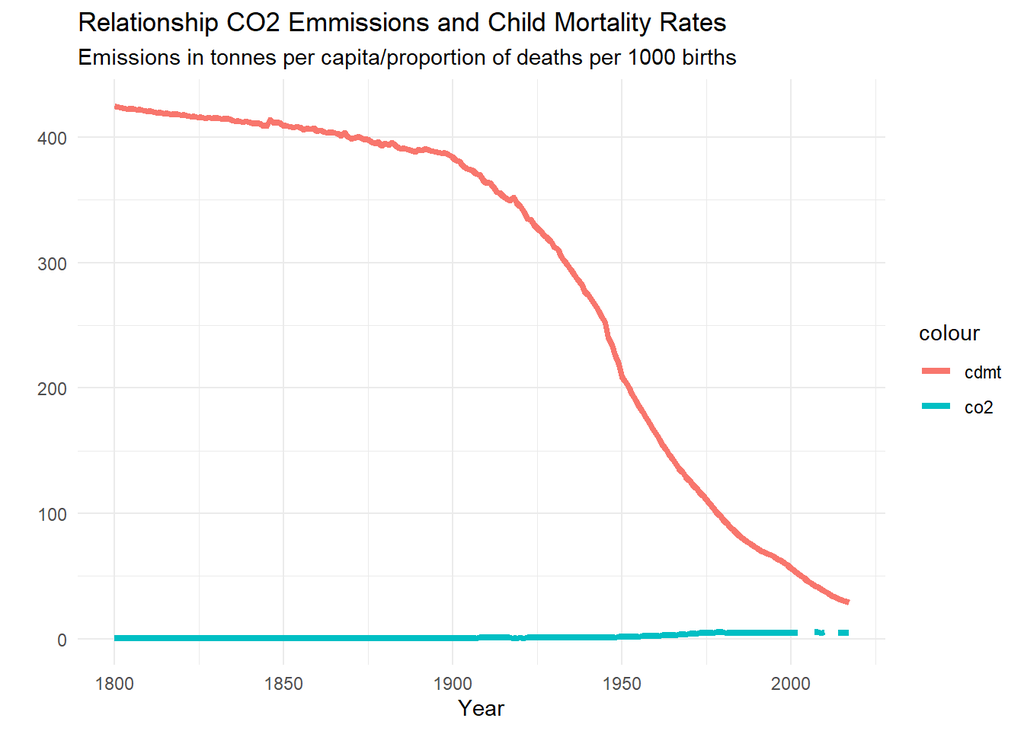

```r
co2_cdmt %>%
  mutate(year = as.numeric(year),
         co2 = as.numeric(co2),
         cdmt = as.numeric(cdmt)) %>%
  group_by(year) %>%
  summarize(avg_co2 = mean(co2),
            avg_cdmt = mean(cdmt)) %>%

  ggplot(aes(x = year)) +
  geom_line(aes(y = avg_co2, color = "co2"), size = 1.5) +
  geom_line(aes(y = avg_cdmt, color = "cdmt"), size = 1.5) +labs(title = "Relationship CO2 Emmissions and Child Mortality Rates",
       x = "Year",
       y = "", subtitle = "Emissions in tonnes per capita/proportion of deaths per 1000 births") +

  theme_minimal()
```

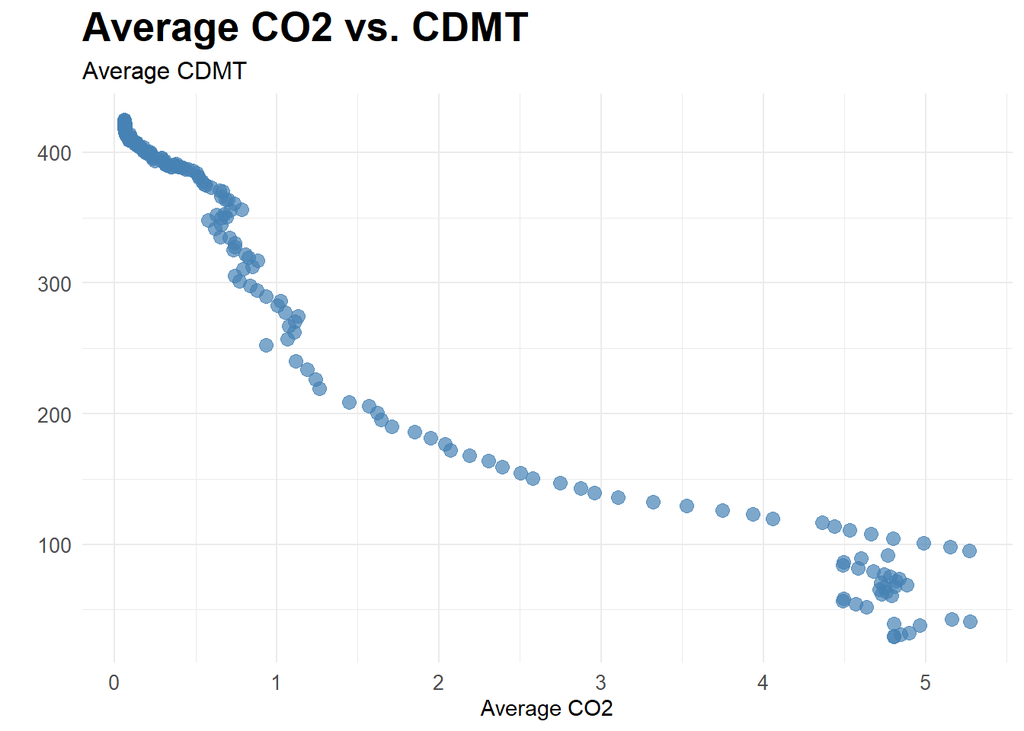

```r
co2_cdmt %>%
  mutate(year = as.numeric(year),
         co2 = as.numeric(co2),
         cdmt = as.numeric(cdmt)) %>%
  group_by(year) %>%
  summarize(avg_co2 = mean(co2),
            avg_cdmt = mean(cdmt)) %>%
  ggplot(aes(x = avg_co2, y = avg_cdmt)) +
  geom_jitter(alpha = 0.7, color = "steelblue", size = 3) +

  labs(title = "Average CO2 vs. CDMT",
       subtitle = "Average CDMT",
       x = "Average CO2",
       y = "") +

  theme_minimal() +
  theme(plot.title = element_text(size = 20, face = "bold"),
        plot.subtitle = element_text(size = 12),
        axis.text = element_text(size = 10))
```